# 교통사고통계

권정환 이도휘

2018년 11월 1일

# 활용 데이터

기상상태별 교통사고.csv 성별 연령층별 시간대별 사상자.csv 연령층별(10세단위) 사상자.csv [TAAS 교통사고분석 시스템](http://taas.koroad.or.kr/)

연령 및 성별 인구 - 읍면동(2015), 시군구(2016~).csv [KOSIS 국가 통계포털](http://kosis.kr/index/index.do)

# 데이터 선정 이유

-교통사고는 우리 주변에서 빈번하게 발생하고 있다. 친척과 친구 포함 주변인 중 꼭 몇 명은 교통사고로 목숨을 잃은 사람이 있을 정도로 매우 흔한 사망원인이다. 본인의 아주 친한 친구도 22세에 교통사고로 사망하였다. 본인도 어렸을 적 갤로퍼에 치여 수 미터를 날아간 적이 있고, 제대 후에는 운전을 하다가 차를 긁은 적이 있다. 아직도 트라우마로 남을 만큼 놀라고 두려운 경험이었다. 이후에는 운전을 하지 않아도 차에 탑승할 때 부모님 차나 택시, 심지어 버스를 탈 때에도 사고가 나면 어떡할까 걱정을 하곤 한다. 건널목을 지날 때에도 좌우를 유심히 살핀 후 건너는 버릇이 생겼다. 현대에는 자동차에 치이는 사고가 많다. 교통사고는 더이상 우리 삶에서 멀리 떨어진 것이 아니다. 영화나 드라마 등에 자주 등장하는 장면들이지만 현실에서도 매우 가까이 있는 위험 요소이기에 더욱 와닿는 장면들이다. 이러하여 본 발표에서는 연령별 교통사고 사망자, 인구대비 교통사고 사망자, 시간대별 교통사고 사망자, 지역별 기상상태별 교통사고 사망자를 분석해보고 교통사고에 대한 경각심을 일깨워주고자 하였다.

# 데이터 분석 방향

-연령별 사망자수를 조사해서 어떤 연령층에서 사망자수가 많은 지를 알아보았다. 연령별 인구대비 사망자수를 조사해서 인구대비 사망자수가 많은 지를 알아보았다. 시간대별로 나누어서 어느 시간대에 사망자가 많이 나왔는가를 연령별로 알아보았다. 지역별로 어느 지역에서 사망자가 많이 나왔고 기상상태별로 날씨가 좋은 날과 나쁜 날에 사망자 수의 차이가 어느 정도가 나는지를 알아보았다.

# **연령별**

```r
library(dplyr)
```

```r
library(tidyr)
library(ggplot2)

a <- read.csv("C://Users//gfdss//Desktop//응데 과제//연령별.csv", stringsAsFactors = F)
colnames(a) <- c("age", "death", "total", "na", "na1", "na2", "na3", "na4", "na5")
head(a)
```

```
##                 age     death total na na1 na2 na3 na4 na5
## 1              합계  사망자수 4,185 NA  NA  NA  NA  NA  NA
## 2              합계 구성비(%) 100.0 NA  NA  NA  NA  NA  NA
## 3          20세이하  사망자수   216 NA  NA  NA  NA  NA  NA
## 4          20세이하 구성비(%) 100.0 NA  NA  NA  NA  NA  NA
## 5 21세이상~30세이하  사망자수   326 NA  NA  NA  NA  NA  NA
## 6 21세이상~30세이하 구성비(%) 100.0 NA  NA  NA  NA  NA  NA
```

```r
a %>% select(c(1, 3)) %>%
  slice(c(3, 5, 7, 9, 11, 13, 15, 17, 19)) %>%
  mutate("age"= as.factor(age), "total" = gsub(",", "", total)) %>%
  mutate("total"=as.numeric(total))-> b
head(b)
```

```
##                 age total
## 1          20세이하   216
## 2 21세이상~30세이하   326
## 3 31세이상~40세이하   326
## 4 41세이상~50세이하   473
## 5 51세이상~60세이하   777
## 6 61세이상~64세이하   306
```

```r
summary(b)
```

```
##                 age        total
##                   :1   Min.   :   2.0
##  20세이하         :1   1st Qu.: 283.5
##  21세이상~30세이하:1   Median : 326.0
##  31세이상~40세이하:1   Mean   : 523.1
##  41세이상~50세이하:1   3rd Qu.: 549.0
##  51세이상~60세이하:1   Max.   :1759.0
##  (Other)          :3   NA's   :1
```

```r
quantile(b$total, na.rm=T)
```

```
##     0%    25%    50%    75%   100%
##    2.0  283.5  326.0  549.0 1759.0
```

```r
IQR(b$total, na.rm=T)
```

```
## [1] 265.5
```

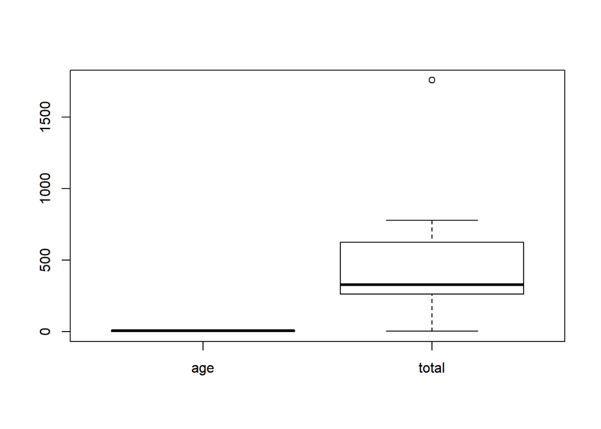

```r
boxplot(b)
```

```r
b$out
```

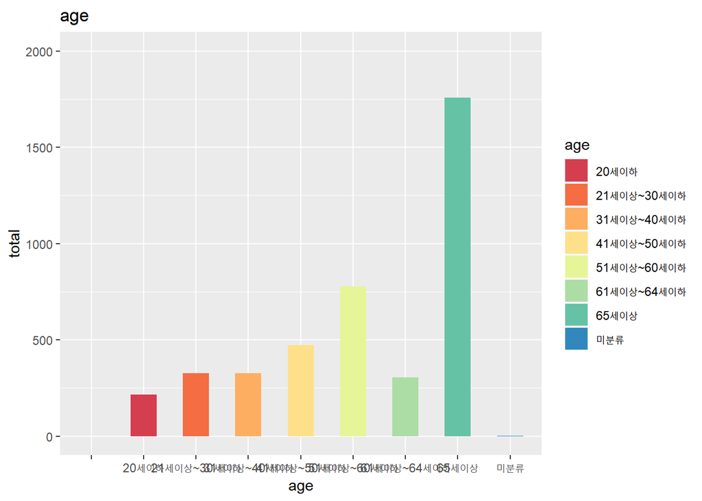

```r
ggplot(data=b, mapping=aes(age, total, fill=age)) +
  geom_bar(stat="identity", width=0.5) +
  coord_cartesian(ylim=c(0, 2000)) +
  labs(title="age") +
  scale_fill_brewer(palette = "Spectral")
```

# **연령별 인구 대비**

```r
f <- read.csv("C://Users//gfdss//Desktop//응데 과제//연령별인구조사.csv",  stringsAsFactors = F)
colnames(f) <- c("state", "age0", "pop0", "age", "pop")
f %>% mutate("age"=as.factor(age)) %>%
  select(c(4,5)) ->g
head(g)
```

```
##                 age      pop
## 1              합계 51422507
## 2          20세이하  9604892
## 3 21세이상~30세이하  6925447
## 4 31세이상~40세이하  7518454
## 5 41세이상~50세이하  8570005
## 6 51세이상~60세이하  8380783
```

```r
left_join(b, g, by="age") ->h
h%>% mutate("age"=as.factor(age)) %>%
  slice(c(1:7)) %>%
  mutate("tp"=(total/pop)*100)-> h1
head(h1)
```

```
##                 age total     pop          tp
## 1          20세이하   216 9604892 0.002248854
## 2 21세이상~30세이하   326 6925447 0.004707277
## 3 31세이상~40세이하   326 7518454 0.004335998
## 4 41세이상~50세이하   473 8570005 0.005519250
## 5 51세이상~60세이하   777 8380783 0.009271210
## 6 61세이상~64세이하   306 5566894 0.005496782
```

```r
summary(h1)
```

```
##                 age        total             pop
##  20세이하         :1   Min.   : 216.0   Min.   :5566894
##  21세이상~30세이하:1   1st Qu.: 316.0   1st Qu.:7048337
##  31세이상~40세이하:1   Median : 326.0   Median :7518454
##  41세이상~50세이하:1   Mean   : 597.6   Mean   :7676815
##  51세이상~60세이하:1   3rd Qu.: 625.0   3rd Qu.:8475394
##  61세이상~64세이하:1   Max.   :1759.0   Max.   :9604892
##  (Other)          :1
##        tp
##  Min.   :0.002249
##  1st Qu.:0.004522
##  Median :0.005497
##  Mean   :0.008015
##  3rd Qu.:0.007395
##  Max.   :0.024529
##
```

```r
quantile(h1$tp, na.rm=T)
```

```
##          0%         25%         50%         75%        100%
## 0.002248854 0.004521638 0.005496782 0.007395230 0.024528578
```

```r
IQR(h1$tp, na.rm=T)
```

```
## [1] 0.002873592
```

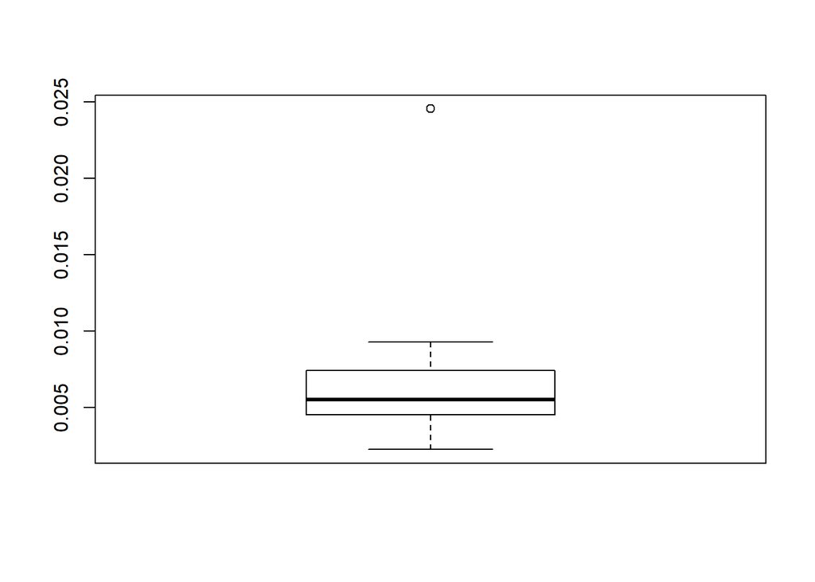

```r
boxplot(h1$tp, na.rm=T)
```

```r
h1$out
```

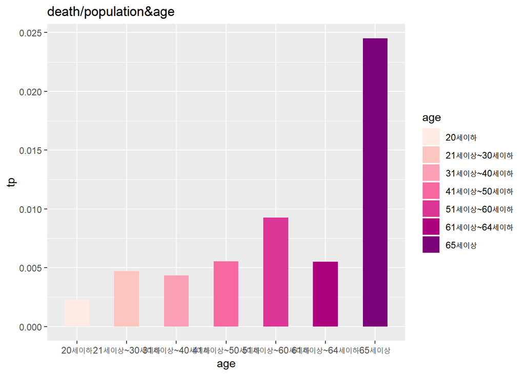

```r
ggplot(h1, aes(age, tp, fill=age)) +
  geom_bar(stat="identity", width=0.5) +
  labs(title="death/population&age") +
  scale_fill_brewer(palette = "RdPu")
```

# **연령별 시간대별**

```r
c <- read.csv("C://Users//gfdss//Desktop//응데 과제//시간대별.csv", stringsAsFactors = F)
colnames(c) <- c("age", "death", "total", "t0t2", "t2t4", "t4t6", "t6t8", "t8t10", "t10t12", "t12t14", "t14t16", "t16t18", "t18t20", "t20t22", "t22t24")
head(c)
```

```
##                 age     death total  t0t2  t2t4  t4t6  t6t8 t8t10 t10t12
## 1              합계  사망자수 4,185 303.0 243.0 350.0 333.0 318.0  363.0
## 2              합계 구성비(%) 100.0   7.2   5.8   8.4   8.0   7.6    8.7
## 3          20세이하  사망자수   216  28.0  21.0  26.0  11.0  12.0    6.0
## 4          20세이하 구성비(%) 100.0  13.0   9.7  12.0   5.1   5.6    2.8
## 5 21세이상~30세이하  사망자수   326  52.0  56.0  48.0  12.0  15.0   12.0
## 6 21세이상~30세이하 구성비(%) 100.0  16.0  17.2  14.7   3.7   4.6    3.7
##   t12t14 t14t16 t16t18 t18t20 t20t22 t22t24
## 1  314.0  371.0  377.0  512.0  369.0  332.0
## 2    7.5    8.9    9.0   12.2    8.8    7.9
## 3    9.0   16.0   20.0   28.0   23.0   16.0
## 4    4.2    7.4    9.3   13.0   10.6    7.4
## 5   11.0   11.0   14.0   19.0   21.0   55.0
## 6    3.4    3.4    4.3    5.8    6.4   16.9
```

```r
c %>% slice(c(1, 3, 5, 7, 9, 11, 13, 15, 17, 19)) %>%
  mutate("age"=as.factor(age), "death"=as.factor(death), "total" = gsub(",", "", total)) %>%
  mutate("total"=as.numeric(total)) -> q
summary(q)
```

```
##                 age         death       total           t0t2
##                   :1           :1   Min.   :   2   Min.   :  1.00
##  20세이하         :1   사망자수:9   1st Qu.: 306   1st Qu.: 24.00
##  21세이상~30세이하:1                Median : 326   Median : 52.00
##  31세이상~40세이하:1                Mean   : 930   Mean   : 67.33
##  41세이상~50세이하:1                3rd Qu.: 777   3rd Qu.: 57.00
##  51세이상~60세이하:1                Max.   :4185   Max.   :303.00
##  (Other)          :4                NA's   :1      NA's   :1
##       t2t4          t4t6             t6t8         t8t10
##  Min.   :  0   Min.   :  0.00   Min.   :  0   Min.   :  0.00
##  1st Qu.: 21   1st Qu.: 26.00   1st Qu.: 11   1st Qu.: 14.00
##  Median : 39   Median : 41.00   Median : 30   Median : 24.00
##  Mean   : 54   Mean   : 77.78   Mean   : 74   Mean   : 70.67
##  3rd Qu.: 43   3rd Qu.: 48.00   3rd Qu.: 58   3rd Qu.: 47.00
##  Max.   :243   Max.   :350.00   Max.   :333   Max.   :318.00
##  NA's   :1     NA's   :1        NA's   :1     NA's   :1
##      t10t12           t12t14           t14t16           t16t18
##  Min.   :  0.00   Min.   :  0.00   Min.   :  0.00   Min.   :  1.00
##  1st Qu.: 12.00   1st Qu.: 11.00   1st Qu.: 16.00   1st Qu.: 18.00
##  Median : 22.00   Median : 20.00   Median : 31.00   Median : 28.00
##  Mean   : 80.67   Mean   : 69.78   Mean   : 82.44   Mean   : 83.78
##  3rd Qu.: 58.00   3rd Qu.: 59.00   3rd Qu.: 53.00   3rd Qu.: 70.00
##  Max.   :363.00   Max.   :314.00   Max.   :371.00   Max.   :377.00
##  NA's   :1        NA's   :1        NA's   :1        NA's   :1
##      t18t20          t20t22        t22t24
##  Min.   :  0.0   Min.   :  0   Min.   :  0.00
##  1st Qu.: 22.0   1st Qu.: 23   1st Qu.: 26.00
##  Median : 47.0   Median : 28   Median : 55.00
##  Mean   :113.8   Mean   : 82   Mean   : 73.78
##  3rd Qu.: 88.0   3rd Qu.:108   3rd Qu.: 58.00
##  Max.   :512.0   Max.   :369   Max.   :332.00
##  NA's   :1       NA's   :1     NA's   :1
```

```r
q %>%  select(c(age, t0t2:t22t24)) %>%
  slice(c(2:9)) %>%
  gather(key='key', value='value', c(t0t2:t22t24)) -> d
colnames(d) <- c("age", "time", "total")
head(d)
```

```
##                 age time total
## 1          20세이하 t0t2    28
## 2 21세이상~30세이하 t0t2    52
## 3 31세이상~40세이하 t0t2    57
## 4 41세이상~50세이하 t0t2    52
## 5 51세이상~60세이하 t0t2    66
## 6 61세이상~64세이하 t0t2    23
```

```r
quantile(d$total, na.rm=T)
```

```
##     0%    25%    50%    75%   100%
##   0.00  14.00  27.50  52.25 255.00
```

```r
IQR(d$total, na.rm=T)
```

```
## [1] 38.25
```

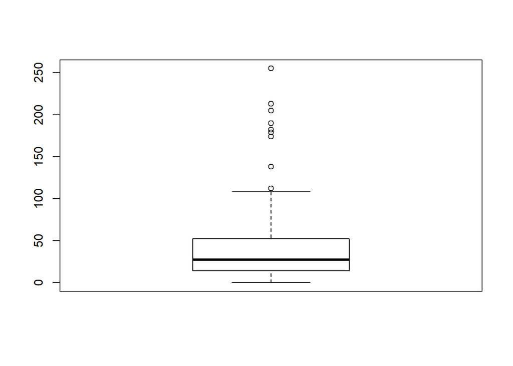

```r
boxplot(d$total, na.rm=T)
```

```r
d$out
```

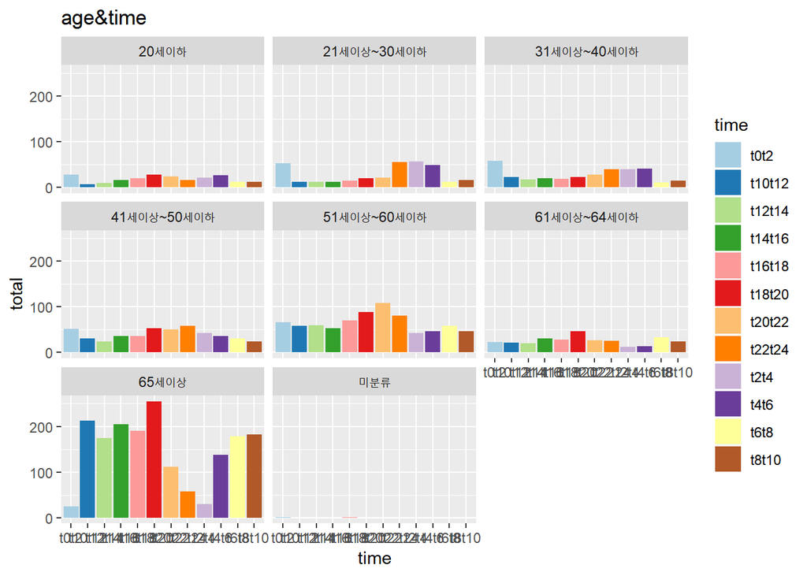

```r
ggplot(d, aes(time, total, fill=time)) +
  facet_wrap(facet=.~age) +
  geom_bar(stat="identity") +
  labs(title="age&time") +
  scale_fill_brewer(palette = "Paired")
```

# **시군구 기상상태별**

```r
w <- read.csv("C://Users//gfdss//Desktop//응데 과제//시군구 날씨별.csv", stringsAsFactors = F)
colnames(w) <- c("state", "state2", "total", "clean", "cloudy", "rain", "fog", "snow", "etc", "none")
head(w)
```

```
##   state state2 total clean cloudy rain fog snow etc none
## 1  합계   합계 4,185 3,575    262  278  17   37  16    0
## 2  서울   합계   343   294     23   21   0    3   2    0
## 3  서울 종로구    13    11      1    1   0    0   0    0
## 4  서울   중구     4     4      0    0   0    0   0    0
## 5  서울 용산구    12    11      1    0   0    0   0    0
## 6  서울 성동구    15    15      0    0   0    0   0    0
```

```r
w %>% mutate("state"= as.factor(state), "total" = gsub(",", "", total), "clean" = gsub(",", "", clean), "cloudy"=as.numeric(cloudy), "rain"=as.numeric(rain), "fog"=as.numeric(fog), "snow"=as.numeric(snow), "etc"=as.numeric(etc)) %>%
  mutate("total"=as.numeric(total), "clean"=as.numeric(clean))-> w3
w3 %>%select(c(1,3,4,5,6,7,8,9)) %>%
  slice(c(2,28,45,54,65,71,77,83,85,117,136,149,166,181,204,228,250))-> w1
head(w1)
```

```
##   state total clean cloudy rain fog snow etc
## 1  서울   343   294     23   21   0    3   2
## 2  부산   164   141      8   14   0    0   1
## 3  대구   148   137      6    5   0    0   0
## 4  인천   105    90      5    6   1    2   1
## 5  광주   120    91     13   14   0    1   1
## 6  대전    86    76      9    1   0    0   0
```

```r
summary(w1)
```

```
##      state        total           clean           cloudy
##  강원   : 1   Min.   : 18.0   Min.   : 15.0   Min.   : 1.00
##  경기   : 1   1st Qu.:105.0   1st Qu.: 90.0   1st Qu.: 8.00
##  경남   : 1   Median :230.0   Median :190.0   Median :15.00
##  경북   : 1   Mean   :246.2   Mean   :210.3   Mean   :15.41
##  광주   : 1   3rd Qu.:343.0   3rd Qu.:294.0   3rd Qu.:21.00
##  대구   : 1   Max.   :784.0   Max.   :664.0   Max.   :51.00
##  (Other):11
##       rain            fog         snow            etc
##  Min.   : 1.00   Min.   :0   Min.   :0.000   Min.   :0.0000
##  1st Qu.: 6.00   1st Qu.:0   1st Qu.:0.000   1st Qu.:0.0000
##  Median :18.00   Median :0   Median :1.000   Median :0.0000
##  Mean   :16.35   Mean   :1   Mean   :2.176   Mean   :0.9412
##  3rd Qu.:22.00   3rd Qu.:1   3rd Qu.:3.000   3rd Qu.:1.0000
##  Max.   :51.00   Max.   :6   Max.   :8.000   Max.   :4.0000
##
```

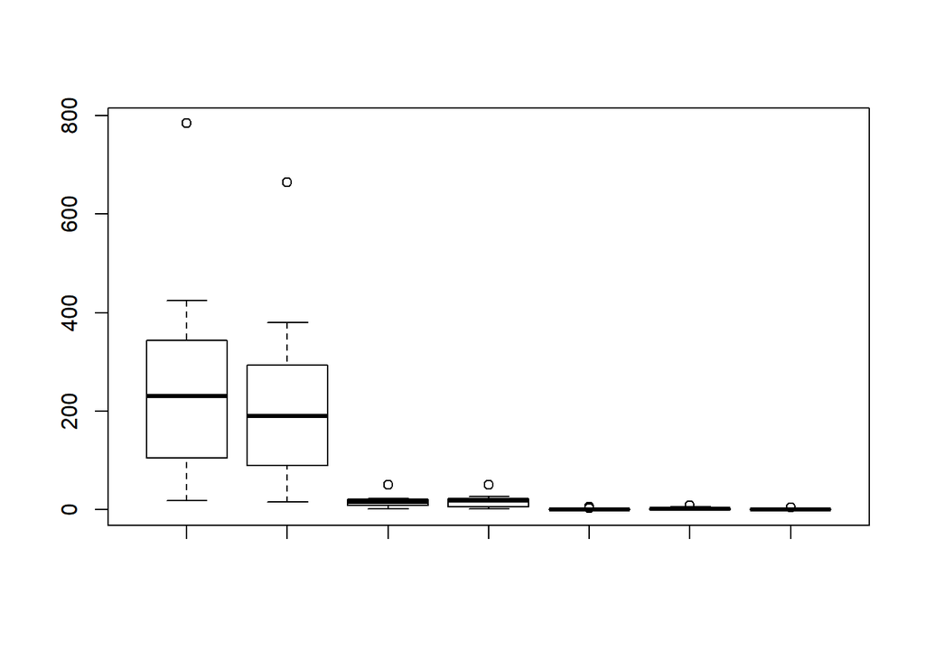

```r
boxplot(w1$total, w1$clean, w1$cloudy, w1$rain, w1$fog, w1$snow, w1$etc, na.rm=T)
```

```r
w1$out
```

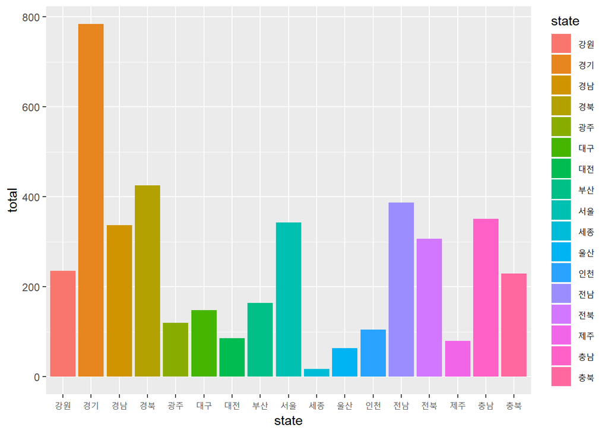

```r
ggplot(w1, aes(state, total, fill=state)) +
  geom_bar(stat="identity")
```

```r
w1 %>%
  gather(key='key', value='value', clean, cloudy, rain, fog, snow, etc) %>%
  mutate("key"=as.factor(key))->w2
colnames(w2) <- c("state", "total", "weather", "n")
head(w2)
```

```
##   state total weather   n
## 1  서울   343   clean 294
## 2  부산   164   clean 141
## 3  대구   148   clean 137
## 4  인천   105   clean  90
## 5  광주   120   clean  91
## 6  대전    86   clean  76
```

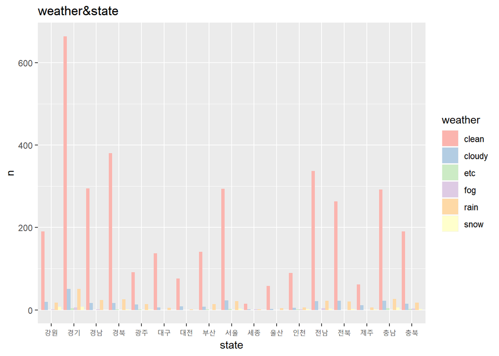

```r
ggplot(w2, aes(state, n, fill=weather)) +
  geom_bar(stat="identity", position = "dodge") +
  labs(title= "weather&state") +
  scale_fill_brewer(palette = "Pastel1")
```

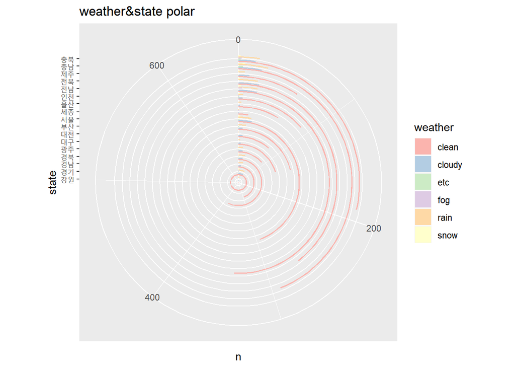

```r
ggplot(w2, aes(state, n, fill=weather)) +
  geom_bar(stat="identity", position = "dodge") +
  coord_polar(theta="y") +
  labs(title= "weather&state polar") +
  scale_fill_brewer(palette = "Pastel1")
```

**outlier** *모든 날씨 범주에서 outlier가 1개씩 존재함을 boxplot을 통해 알 수 있다.

# 알게 된 사실

연령별 사망자수는 연령과 사망자수가 정적상관을 보인다. 연령별 인구대비 사망자수는 연령별 사망자수와 거의 유사한 상관관계를 가지고 있다. 연령별 시간대별 사망자수를 확인해본 결과 그 연령대에 야외활동하는 시간대에 많이 사망한다는 것을 알 수 있다. 시도별 사망자수에서는 의외로 광역시에서 사망자수가 적다는 사실을 알 수 있다. 기상상태별 사망자수에서는 기상상태가 불량한 날에 사망자 수가 많을 것 같던 예상을 깨고 상태가 좋은 날이 압도적으로 많다는 사실을 알 수 있다.

# 추후 계획

*기상상태별 자료에서 비나 눈이 올 때 교통사고 사망자가 많을 것이라는 예상을 깨고 맑음일 때 가장 사망자가 많은 것으로 보아 날씨별 빈도가 결과에 영향을 준 것으로 보인다. 따라서 날씨별 빈도 자료와 기상상태별 자료를 조인해 기상상태 대비 교통사고 사망자수에 대한 데이터를 새로 추가해볼 것이다.

*시군구별 사망사고 데이터를 참조해 교통사고 지도를 ggmap 패키지로 작성해 볼 것이다.